# Risk Factor Analysis

## Outcome Variable

**Outcome Variable:** ever_co

## Predictor Variables

**Intervention Variable:** nchldlt5

**Adjustment Set:**

- arm
- W_mage
- meducyrs
- feducyrs
- hhwealth_quart
- hfoodsec
- W_mhtcm
- W_nrooms
- W_parity
- impfloor
- impsan
- safeh20
- delta_W_mage
- delta_meducyrs
- delta_feducyrs
- delta_hhwealth_quart
- delta_hfoodsec
- delta_W_mhtcm
- delta_W_nrooms
- delta_W_parity
- delta_impfloor
- delta_impsan
- delta_safeh20

## Stratifying Variables

The analysis was stratified on these variable(s):

- agecat
- studyid
- country

## Data Summary

| agecat | studyid | country | nchldlt5 | ever_co | n_cell | n |
| --- | --- | --- | --- | --- | --- | --- |
| 0-24 months | ki1000108-IRC | INDIA | 1 | 0 | 69 | 410 |
| 0-24 months | ki1000108-IRC | INDIA | 1 | 1 | 20 | 410 |
| 0-24 months | ki1000108-IRC | INDIA | 2+ | 0 | 265 | 410 |
| 0-24 months | ki1000108-IRC | INDIA | 2+ | 1 | 56 | 410 |
| 0-24 months | ki1017093b-PROVIDE | BANGLADESH | 1 | 0 | 447 | 700 |
| 0-24 months | ki1017093b-PROVIDE | BANGLADESH | 1 | 1 | 65 | 700 |
| 0-24 months | ki1017093b-PROVIDE | BANGLADESH | 2+ | 0 | 163 | 700 |
| 0-24 months | ki1017093b-PROVIDE | BANGLADESH | 2+ | 1 | 25 | 700 |
| 0-24 months | ki1017093c-NIH-Crypto | BANGLADESH | 1 | 0 | 496 | 758 |
| 0-24 months | ki1017093c-NIH-Crypto | BANGLADESH | 1 | 1 | 45 | 758 |
| 0-24 months | ki1017093c-NIH-Crypto | BANGLADESH | 2+ | 0 | 191 | 758 |
| 0-24 months | ki1017093c-NIH-Crypto | BANGLADESH | 2+ | 1 | 26 | 758 |
| 0-24 months | ki1066203-TanzaniaChild2 | TANZANIA, UNITED REPUBLIC OF | 1 | 0 | 1552 | 2385 |
| 0-24 months | ki1066203-TanzaniaChild2 | TANZANIA, UNITED REPUBLIC OF | 1 | 1 | 85 | 2385 |
| 0-24 months | ki1066203-TanzaniaChild2 | TANZANIA, UNITED REPUBLIC OF | 2+ | 0 | 714 | 2385 |
| 0-24 months | ki1066203-TanzaniaChild2 | TANZANIA, UNITED REPUBLIC OF | 2+ | 1 | 34 | 2385 |
| 0-24 months | ki1112895-iLiNS-Zinc | BURKINA FASO | 1 | 0 | 956 | 3188 |
| 0-24 months | ki1112895-iLiNS-Zinc | BURKINA FASO | 1 | 1 | 117 | 3188 |
| 0-24 months | ki1112895-iLiNS-Zinc | BURKINA FASO | 2+ | 0 | 1849 | 3188 |
| 0-24 months | ki1112895-iLiNS-Zinc | BURKINA FASO | 2+ | 1 | 266 | 3188 |
| 0-24 months | ki1148112-LCNI-5 | MALAWI | 1 | 0 | 376 | 812 |
| 0-24 months | ki1148112-LCNI-5 | MALAWI | 1 | 1 | 15 | 812 |
| 0-24 months | ki1148112-LCNI-5 | MALAWI | 2+ | 0 | 394 | 812 |
| 0-24 months | ki1148112-LCNI-5 | MALAWI | 2+ | 1 | 27 | 812 |
| 0-24 months | kiGH5241-JiVitA-3 | BANGLADESH | 1 | 0 | 15663 | 26900 |
| 0-24 months | kiGH5241-JiVitA-3 | BANGLADESH | 1 | 1 | 1535 | 26900 |
| 0-24 months | kiGH5241-JiVitA-3 | BANGLADESH | 2+ | 0 | 8856 | 26900 |
| 0-24 months | kiGH5241-JiVitA-3 | BANGLADESH | 2+ | 1 | 846 | 26900 |
| 0-6 months | ki1000108-IRC | INDIA | 1 | 0 | 79 | 409 |
| 0-6 months | ki1000108-IRC | INDIA | 1 | 1 | 10 | 409 |
| 0-6 months | ki1000108-IRC | INDIA | 2+ | 0 | 305 | 409 |
| 0-6 months | ki1000108-IRC | INDIA | 2+ | 1 | 15 | 409 |
| 0-6 months | ki1017093b-PROVIDE | BANGLADESH | 1 | 0 | 491 | 700 |
| 0-6 months | ki1017093b-PROVIDE | BANGLADESH | 1 | 1 | 21 | 700 |
| 0-6 months | ki1017093b-PROVIDE | BANGLADESH | 2+ | 0 | 179 | 700 |
| 0-6 months | ki1017093b-PROVIDE | BANGLADESH | 2+ | 1 | 9 | 700 |
| 0-6 months | ki1017093c-NIH-Crypto | BANGLADESH | 1 | 0 | 531 | 758 |
| 0-6 months | ki1017093c-NIH-Crypto | BANGLADESH | 1 | 1 | 10 | 758 |
| 0-6 months | ki1017093c-NIH-Crypto | BANGLADESH | 2+ | 0 | 210 | 758 |
| 0-6 months | ki1017093c-NIH-Crypto | BANGLADESH | 2+ | 1 | 7 | 758 |
| 0-6 months | ki1066203-TanzaniaChild2 | TANZANIA, UNITED REPUBLIC OF | 1 | 0 | 1622 | 2385 |
| 0-6 months | ki1066203-TanzaniaChild2 | TANZANIA, UNITED REPUBLIC OF | 1 | 1 | 15 | 2385 |
| 0-6 months | ki1066203-TanzaniaChild2 | TANZANIA, UNITED REPUBLIC OF | 2+ | 0 | 744 | 2385 |
| 0-6 months | ki1066203-TanzaniaChild2 | TANZANIA, UNITED REPUBLIC OF | 2+ | 1 | 4 | 2385 |
| 0-6 months | ki1148112-LCNI-5 | MALAWI | 1 | 0 | 122 | 267 |
| 0-6 months | ki1148112-LCNI-5 | MALAWI | 1 | 1 | 0 | 267 |
| 0-6 months | ki1148112-LCNI-5 | MALAWI | 2+ | 0 | 145 | 267 |
| 0-6 months | ki1148112-LCNI-5 | MALAWI | 2+ | 1 | 0 | 267 |
| 0-6 months | kiGH5241-JiVitA-3 | BANGLADESH | 1 | 0 | 16387 | 26793 |
| 0-6 months | kiGH5241-JiVitA-3 | BANGLADESH | 1 | 1 | 725 | 26793 |
| 0-6 months | kiGH5241-JiVitA-3 | BANGLADESH | 2+ | 0 | 9352 | 26793 |
| 0-6 months | kiGH5241-JiVitA-3 | BANGLADESH | 2+ | 1 | 329 | 26793 |
| 6-24 months | ki1000108-IRC | INDIA | 1 | 0 | 73 | 410 |
| 6-24 months | ki1000108-IRC | INDIA | 1 | 1 | 16 | 410 |
| 6-24 months | ki1000108-IRC | INDIA | 2+ | 0 | 273 | 410 |
| 6-24 months | ki1000108-IRC | INDIA | 2+ | 1 | 48 | 410 |
| 6-24 months | ki1017093b-PROVIDE | BANGLADESH | 1 | 0 | 396 | 614 |
| 6-24 months | ki1017093b-PROVIDE | BANGLADESH | 1 | 1 | 52 | 614 |
| 6-24 months | ki1017093b-PROVIDE | BANGLADESH | 2+ | 0 | 143 | 614 |
| 6-24 months | ki1017093b-PROVIDE | BANGLADESH | 2+ | 1 | 23 | 614 |
| 6-24 months | ki1017093c-NIH-Crypto | BANGLADESH | 1 | 0 | 481 | 730 |
| 6-24 months | ki1017093c-NIH-Crypto | BANGLADESH | 1 | 1 | 39 | 730 |
| 6-24 months | ki1017093c-NIH-Crypto | BANGLADESH | 2+ | 0 | 186 | 730 |
| 6-24 months | ki1017093c-NIH-Crypto | BANGLADESH | 2+ | 1 | 24 | 730 |
| 6-24 months | ki1066203-TanzaniaChild2 | TANZANIA, UNITED REPUBLIC OF | 1 | 0 | 1303 | 2009 |
| 6-24 months | ki1066203-TanzaniaChild2 | TANZANIA, UNITED REPUBLIC OF | 1 | 1 | 80 | 2009 |
| 6-24 months | ki1066203-TanzaniaChild2 | TANZANIA, UNITED REPUBLIC OF | 2+ | 0 | 593 | 2009 |
| 6-24 months | ki1066203-TanzaniaChild2 | TANZANIA, UNITED REPUBLIC OF | 2+ | 1 | 33 | 2009 |
| 6-24 months | ki1112895-iLiNS-Zinc | BURKINA FASO | 1 | 0 | 956 | 3188 |
| 6-24 months | ki1112895-iLiNS-Zinc | BURKINA FASO | 1 | 1 | 117 | 3188 |
| 6-24 months | ki1112895-iLiNS-Zinc | BURKINA FASO | 2+ | 0 | 1849 | 3188 |
| 6-24 months | ki1112895-iLiNS-Zinc | BURKINA FASO | 2+ | 1 | 266 | 3188 |
| 6-24 months | ki1148112-LCNI-5 | MALAWI | 1 | 0 | 369 | 800 |
| 6-24 months | ki1148112-LCNI-5 | MALAWI | 1 | 1 | 15 | 800 |
| 6-24 months | ki1148112-LCNI-5 | MALAWI | 2+ | 0 | 389 | 800 |
| 6-24 months | ki1148112-LCNI-5 | MALAWI | 2+ | 1 | 27 | 800 |
| 6-24 months | kiGH5241-JiVitA-3 | BANGLADESH | 1 | 0 | 10266 | 17268 |
| 6-24 months | kiGH5241-JiVitA-3 | BANGLADESH | 1 | 1 | 924 | 17268 |
| 6-24 months | kiGH5241-JiVitA-3 | BANGLADESH | 2+ | 0 | 5503 | 17268 |
| 6-24 months | kiGH5241-JiVitA-3 | BANGLADESH | 2+ | 1 | 575 | 17268 |

The following strata were considered:

- agecat: 0-24 months, studyid: ki1000108-IRC, country: INDIA
- agecat: 0-24 months, studyid: ki1017093b-PROVIDE, country: BANGLADESH
- agecat: 0-24 months, studyid: ki1017093c-NIH-Crypto, country: BANGLADESH
- agecat: 0-24 months, studyid: ki1066203-TanzaniaChild2, country: TANZANIA, UNITED REPUBLIC OF
- agecat: 0-24 months, studyid: ki1112895-iLiNS-Zinc, country: BURKINA FASO
- agecat: 0-24 months, studyid: ki1148112-LCNI-5, country: MALAWI
- agecat: 0-24 months, studyid: kiGH5241-JiVitA-3, country: BANGLADESH
- agecat: 0-6 months, studyid: ki1000108-IRC, country: INDIA
- agecat: 0-6 months, studyid: ki1017093b-PROVIDE, country: BANGLADESH
- agecat: 0-6 months, studyid: ki1017093c-NIH-Crypto, country: BANGLADESH
- agecat: 0-6 months, studyid: ki1066203-TanzaniaChild2, country: TANZANIA, UNITED REPUBLIC OF
- agecat: 0-6 months, studyid: ki1148112-LCNI-5, country: MALAWI
- agecat: 0-6 months, studyid: kiGH5241-JiVitA-3, country: BANGLADESH
- agecat: 6-24 months, studyid: ki1000108-IRC, country: INDIA
- agecat: 6-24 months, studyid: ki1017093b-PROVIDE, country: BANGLADESH
- agecat: 6-24 months, studyid: ki1017093c-NIH-Crypto, country: BANGLADESH
- agecat: 6-24 months, studyid: ki1066203-TanzaniaChild2, country: TANZANIA, UNITED REPUBLIC OF
- agecat: 6-24 months, studyid: ki1112895-iLiNS-Zinc, country: BURKINA FASO
- agecat: 6-24 months, studyid: ki1148112-LCNI-5, country: MALAWI
- agecat: 6-24 months, studyid: kiGH5241-JiVitA-3, country: BANGLADESH

### Dropped Strata

Some strata were dropped due to rare outcomes:

- agecat: 0-6 months, studyid: ki1066203-TanzaniaChild2, country: TANZANIA, UNITED REPUBLIC OF
- agecat: 0-6 months, studyid: ki1148112-LCNI-5, country: MALAWI

## Methods Detail

We’re interested in the causal parameters $E[Y_a]$ for all values of $a \in \mathcal{A}$. These parameters represent the mean outcome if, possibly contrary to fact, we intervened to set all units to have $A=a$. Under the randomization and positivity assumptions, these are identified by the statistical parameters $\psi_a=E_W[E_{Y|A,W}(Y|A=a,W)]$. In addition, we’re interested in the mean of $Y$, $E[Y]$ under no intervention (the observed mean). We will estimate these parameters by using SuperLearner to fit the relevant likelihood factors – $E_{Y|A,W}(Y|A=a,W)$ and $p(A=a|W)$, and then updating our likelihood fit using a joint TMLE.

For unadjusted analyses ($W=\{\}$), initial likelihoods were estimated using Lrnr_glm to estimate the simple $E(Y|A)$ and Lrnr_mean to estimate $p(A)$. For adjusted analyses, a small library containing Lrnr_glmnet, Lrnr_xgboost, and Lrnr_mean was used.

Having estimated these parameters, we will then use the delta method to estimate relative risks and attributable risks relative to a prespecified baseline level of $A$.

# Results Detail

## Results Plots

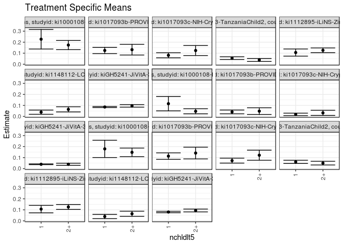

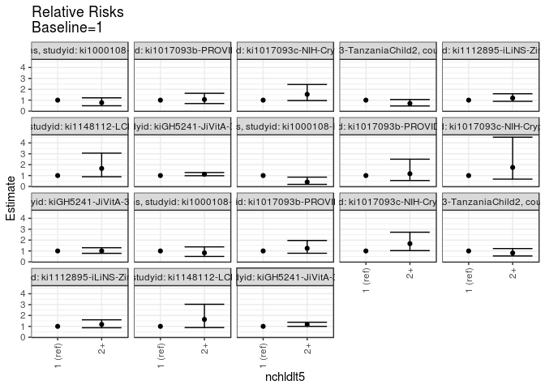

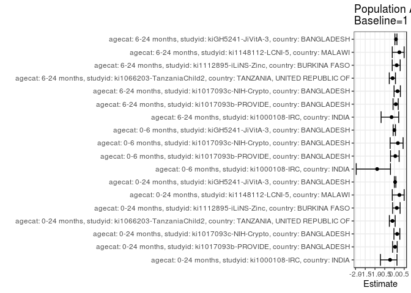

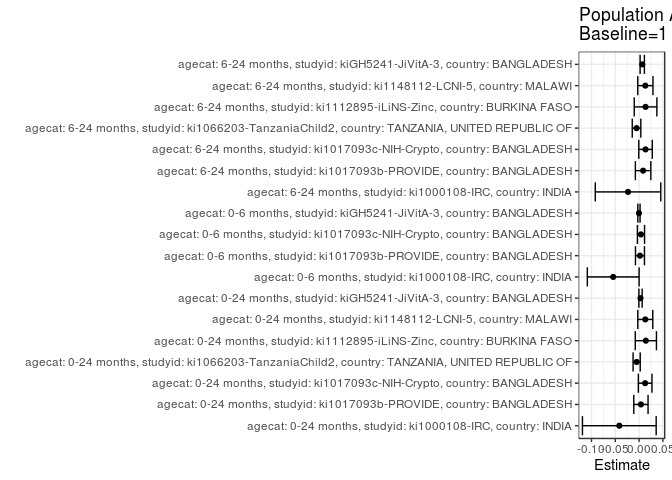

## Results Table

### Parameter: TSM

| agecat | studyid | country | intervention_level | baseline_level | estimate | ci_lower | ci_upper |
| --- | --- | --- | --- | --- | --- | --- | --- |
| 0-24 months | ki1000108-IRC | INDIA | 1 | NA | 0.2269227 | 0.1379108 | 0.3159346 |
| 0-24 months | ki1000108-IRC | INDIA | 2+ | NA | 0.1738810 | 0.1323481 | 0.2154139 |
| 0-24 months | ki1017093b-PROVIDE | BANGLADESH | 1 | NA | 0.1247322 | 0.0961932 | 0.1532711 |
| 0-24 months | ki1017093b-PROVIDE | BANGLADESH | 2+ | NA | 0.1320473 | 0.0835625 | 0.1805321 |
| 0-24 months | ki1017093c-NIH-Crypto | BANGLADESH | 1 | NA | 0.0809091 | 0.0578026 | 0.1040157 |
| 0-24 months | ki1017093c-NIH-Crypto | BANGLADESH | 2+ | NA | 0.1241815 | 0.0786536 | 0.1697094 |
| 0-24 months | ki1066203-TanzaniaChild2 | TANZANIA, UNITED REPUBLIC OF | 1 | NA | 0.0550197 | 0.0427706 | 0.0672688 |
| 0-24 months | ki1066203-TanzaniaChild2 | TANZANIA, UNITED REPUBLIC OF | 2+ | NA | 0.0385595 | 0.0251633 | 0.0519557 |
| 0-24 months | ki1112895-iLiNS-Zinc | BURKINA FASO | 1 | NA | 0.1059330 | 0.0734934 | 0.1383726 |
| 0-24 months | ki1112895-iLiNS-Zinc | BURKINA FASO | 2+ | NA | 0.1261609 | 0.1044743 | 0.1478474 |
| 0-24 months | ki1148112-LCNI-5 | MALAWI | 1 | NA | 0.0386987 | 0.0195281 | 0.0578692 |
| 0-24 months | ki1148112-LCNI-5 | MALAWI | 2+ | NA | 0.0639433 | 0.0405571 | 0.0873296 |
| 0-24 months | kiGH5241-JiVitA-3 | BANGLADESH | 1 | NA | 0.0855149 | 0.0805308 | 0.0904989 |
| 0-24 months | kiGH5241-JiVitA-3 | BANGLADESH | 2+ | NA | 0.0958927 | 0.0843485 | 0.1074368 |
| 0-6 months | ki1000108-IRC | INDIA | 1 | NA | 0.1155173 | 0.0501546 | 0.1808800 |
| 0-6 months | ki1000108-IRC | INDIA | 2+ | NA | 0.0467146 | 0.0236204 | 0.0698089 |
| 0-6 months | ki1017093b-PROVIDE | BANGLADESH | 1 | NA | 0.0410156 | 0.0238245 | 0.0582067 |
| 0-6 months | ki1017093b-PROVIDE | BANGLADESH | 2+ | NA | 0.0478723 | 0.0173323 | 0.0784124 |
| 0-6 months | ki1017093c-NIH-Crypto | BANGLADESH | 1 | NA | 0.0184843 | 0.0071267 | 0.0298419 |
| 0-6 months | ki1017093c-NIH-Crypto | BANGLADESH | 2+ | NA | 0.0322581 | 0.0087345 | 0.0557817 |
| 0-6 months | kiGH5241-JiVitA-3 | BANGLADESH | 1 | NA | 0.0396191 | 0.0362496 | 0.0429887 |
| 0-6 months | kiGH5241-JiVitA-3 | BANGLADESH | 2+ | NA | 0.0398346 | 0.0301717 | 0.0494974 |
| 6-24 months | ki1000108-IRC | INDIA | 1 | NA | 0.1793494 | 0.1007127 | 0.2579861 |
| 6-24 months | ki1000108-IRC | INDIA | 2+ | NA | 0.1479467 | 0.1091000 | 0.1867935 |
| 6-24 months | ki1017093b-PROVIDE | BANGLADESH | 1 | NA | 0.1137080 | 0.0843567 | 0.1430593 |
| 6-24 months | ki1017093b-PROVIDE | BANGLADESH | 2+ | NA | 0.1414439 | 0.0882202 | 0.1946675 |
| 6-24 months | ki1017093c-NIH-Crypto | BANGLADESH | 1 | NA | 0.0727680 | 0.0502801 | 0.0952559 |
| 6-24 months | ki1017093c-NIH-Crypto | BANGLADESH | 2+ | NA | 0.1218380 | 0.0760144 | 0.1676617 |
| 6-24 months | ki1066203-TanzaniaChild2 | TANZANIA, UNITED REPUBLIC OF | 1 | NA | 0.0616198 | 0.0472288 | 0.0760108 |
| 6-24 months | ki1066203-TanzaniaChild2 | TANZANIA, UNITED REPUBLIC OF | 2+ | NA | 0.0499449 | 0.0331599 | 0.0667298 |
| 6-24 months | ki1112895-iLiNS-Zinc | BURKINA FASO | 1 | NA | 0.1065530 | 0.0726581 | 0.1404479 |
| 6-24 months | ki1112895-iLiNS-Zinc | BURKINA FASO | 2+ | NA | 0.1260093 | 0.1036365 | 0.1483820 |
| 6-24 months | ki1148112-LCNI-5 | MALAWI | 1 | NA | 0.0393496 | 0.0199387 | 0.0587606 |
| 6-24 months | ki1148112-LCNI-5 | MALAWI | 2+ | NA | 0.0645162 | 0.0410446 | 0.0879878 |
| 6-24 months | kiGH5241-JiVitA-3 | BANGLADESH | 1 | NA | 0.0801569 | 0.0738708 | 0.0864430 |
| 6-24 months | kiGH5241-JiVitA-3 | BANGLADESH | 2+ | NA | 0.0940812 | 0.0810370 | 0.1071254 |

### Parameter: E(Y)

| agecat | studyid | country | intervention_level | baseline_level | estimate | ci_lower | ci_upper |
| --- | --- | --- | --- | --- | --- | --- | --- |
| 0-24 months | ki1000108-IRC | INDIA | NA | NA | 0.1853659 | 0.1477057 | 0.2230261 |
| 0-24 months | ki1017093b-PROVIDE | BANGLADESH | NA | NA | 0.1285714 | 0.1037574 | 0.1533855 |
| 0-24 months | ki1017093c-NIH-Crypto | BANGLADESH | NA | NA | 0.0936675 | 0.0729118 | 0.1144233 |
| 0-24 months | ki1066203-TanzaniaChild2 | TANZANIA, UNITED REPUBLIC OF | NA | NA | 0.0498952 | 0.0411552 | 0.0586351 |
| 0-24 months | ki1112895-iLiNS-Zinc | BURKINA FASO | NA | NA | 0.1201380 | 0.1003403 | 0.1399357 |
| 0-24 months | ki1148112-LCNI-5 | MALAWI | NA | NA | 0.0517241 | 0.0364818 | 0.0669665 |
| 0-24 months | kiGH5241-JiVitA-3 | BANGLADESH | NA | NA | 0.0885130 | 0.0846366 | 0.0923894 |
| 0-6 months | ki1000108-IRC | INDIA | NA | NA | 0.0611247 | 0.0378797 | 0.0843697 |
| 0-6 months | ki1017093b-PROVIDE | BANGLADESH | NA | NA | 0.0428571 | 0.0278427 | 0.0578716 |
| 0-6 months | ki1017093c-NIH-Crypto | BANGLADESH | NA | NA | 0.0224274 | 0.0118796 | 0.0329753 |
| 0-6 months | kiGH5241-JiVitA-3 | BANGLADESH | NA | NA | 0.0393386 | 0.0368539 | 0.0418234 |
| 6-24 months | ki1000108-IRC | INDIA | NA | NA | 0.1560976 | 0.1209228 | 0.1912723 |
| 6-24 months | ki1017093b-PROVIDE | BANGLADESH | NA | NA | 0.1221498 | 0.0962275 | 0.1480722 |
| 6-24 months | ki1017093c-NIH-Crypto | BANGLADESH | NA | NA | 0.0863014 | 0.0659171 | 0.1066856 |
| 6-24 months | ki1066203-TanzaniaChild2 | TANZANIA, UNITED REPUBLIC OF | NA | NA | 0.0562469 | 0.0461696 | 0.0663242 |
| 6-24 months | ki1112895-iLiNS-Zinc | BURKINA FASO | NA | NA | 0.1201380 | 0.1003403 | 0.1399357 |
| 6-24 months | ki1148112-LCNI-5 | MALAWI | NA | NA | 0.0525000 | 0.0370352 | 0.0679648 |
| 6-24 months | kiGH5241-JiVitA-3 | BANGLADESH | NA | NA | 0.0868080 | 0.0821488 | 0.0914672 |

### Parameter: RR

| agecat | studyid | country | intervention_level | baseline_level | estimate | ci_lower | ci_upper |
| --- | --- | --- | --- | --- | --- | --- | --- |
| 0-24 months | ki1000108-IRC | INDIA | 1 | 1 | 1.0000000 | 1.0000000 | 1.0000000 |
| 0-24 months | ki1000108-IRC | INDIA | 2+ | 1 | 0.7662566 | 0.4838997 | 1.2133696 |
| 0-24 months | ki1017093b-PROVIDE | BANGLADESH | 1 | 1 | 1.0000000 | 1.0000000 | 1.0000000 |
| 0-24 months | ki1017093b-PROVIDE | BANGLADESH | 2+ | 1 | 1.0586470 | 0.6873746 | 1.6304554 |
| 0-24 months | ki1017093c-NIH-Crypto | BANGLADESH | 1 | 1 | 1.0000000 | 1.0000000 | 1.0000000 |
| 0-24 months | ki1017093c-NIH-Crypto | BANGLADESH | 2+ | 1 | 1.5348269 | 0.9648802 | 2.4414366 |
| 0-24 months | ki1066203-TanzaniaChild2 | TANZANIA, UNITED REPUBLIC OF | 1 | 1 | 1.0000000 | 1.0000000 | 1.0000000 |
| 0-24 months | ki1066203-TanzaniaChild2 | TANZANIA, UNITED REPUBLIC OF | 2+ | 1 | 0.7008310 | 0.4639666 | 1.0586197 |
| 0-24 months | ki1112895-iLiNS-Zinc | BURKINA FASO | 1 | 1 | 1.0000000 | 1.0000000 | 1.0000000 |
| 0-24 months | ki1112895-iLiNS-Zinc | BURKINA FASO | 2+ | 1 | 1.1909497 | 0.8927300 | 1.5887910 |
| 0-24 months | ki1148112-LCNI-5 | MALAWI | 1 | 1 | 1.0000000 | 1.0000000 | 1.0000000 |
| 0-24 months | ki1148112-LCNI-5 | MALAWI | 2+ | 1 | 1.6523391 | 0.8924501 | 3.0592461 |
| 0-24 months | kiGH5241-JiVitA-3 | BANGLADESH | 1 | 1 | 1.0000000 | 1.0000000 | 1.0000000 |
| 0-24 months | kiGH5241-JiVitA-3 | BANGLADESH | 2+ | 1 | 1.1213567 | 0.9839061 | 1.2780090 |
| 0-6 months | ki1000108-IRC | INDIA | 1 | 1 | 1.0000000 | 1.0000000 | 1.0000000 |
| 0-6 months | ki1000108-IRC | INDIA | 2+ | 1 | 0.4043952 | 0.1914295 | 0.8542858 |
| 0-6 months | ki1017093b-PROVIDE | BANGLADESH | 1 | 1 | 1.0000000 | 1.0000000 | 1.0000000 |
| 0-6 months | ki1017093b-PROVIDE | BANGLADESH | 2+ | 1 | 1.1671733 | 0.5440406 | 2.5040289 |
| 0-6 months | ki1017093c-NIH-Crypto | BANGLADESH | 1 | 1 | 1.0000000 | 1.0000000 | 1.0000000 |
| 0-6 months | ki1017093c-NIH-Crypto | BANGLADESH | 2+ | 1 | 1.7451613 | 0.6725110 | 4.5286812 |
| 0-6 months | kiGH5241-JiVitA-3 | BANGLADESH | 1 | 1 | 1.0000000 | 1.0000000 | 1.0000000 |
| 0-6 months | kiGH5241-JiVitA-3 | BANGLADESH | 2+ | 1 | 1.0054376 | 0.7808913 | 1.2945525 |
| 6-24 months | ki1000108-IRC | INDIA | 1 | 1 | 1.0000000 | 1.0000000 | 1.0000000 |
| 6-24 months | ki1000108-IRC | INDIA | 2+ | 1 | 0.8249078 | 0.4948240 | 1.3751818 |
| 6-24 months | ki1017093b-PROVIDE | BANGLADESH | 1 | 1 | 1.0000000 | 1.0000000 | 1.0000000 |
| 6-24 months | ki1017093b-PROVIDE | BANGLADESH | 2+ | 1 | 1.2439217 | 0.7882709 | 1.9629561 |
| 6-24 months | ki1017093c-NIH-Crypto | BANGLADESH | 1 | 1 | 1.0000000 | 1.0000000 | 1.0000000 |
| 6-24 months | ki1017093c-NIH-Crypto | BANGLADESH | 2+ | 1 | 1.6743348 | 1.0296124 | 2.7227693 |
| 6-24 months | ki1066203-TanzaniaChild2 | TANZANIA, UNITED REPUBLIC OF | 1 | 1 | 1.0000000 | 1.0000000 | 1.0000000 |
| 6-24 months | ki1066203-TanzaniaChild2 | TANZANIA, UNITED REPUBLIC OF | 2+ | 1 | 0.8105330 | 0.5382878 | 1.2204694 |
| 6-24 months | ki1112895-iLiNS-Zinc | BURKINA FASO | 1 | 1 | 1.0000000 | 1.0000000 | 1.0000000 |
| 6-24 months | ki1112895-iLiNS-Zinc | BURKINA FASO | 2+ | 1 | 1.1825972 | 0.8727873 | 1.6023791 |
| 6-24 months | ki1148112-LCNI-5 | MALAWI | 1 | 1 | 1.0000000 | 1.0000000 | 1.0000000 |
| 6-24 months | ki1148112-LCNI-5 | MALAWI | 2+ | 1 | 1.6395634 | 0.8876970 | 3.0282497 |
| 6-24 months | kiGH5241-JiVitA-3 | BANGLADESH | 1 | 1 | 1.0000000 | 1.0000000 | 1.0000000 |
| 6-24 months | kiGH5241-JiVitA-3 | BANGLADESH | 2+ | 1 | 1.1737125 | 1.0009601 | 1.3762796 |

### Parameter: PAR

| agecat | studyid | country | intervention_level | baseline_level | estimate | ci_lower | ci_upper |
| --- | --- | --- | --- | --- | --- | --- | --- |
| 0-24 months | ki1000108-IRC | INDIA | 1 | NA | -0.0415569 | -0.1190062 | 0.0358925 |
| 0-24 months | ki1017093b-PROVIDE | BANGLADESH | 1 | NA | 0.0038393 | -0.0111592 | 0.0188377 |
| 0-24 months | ki1017093c-NIH-Crypto | BANGLADESH | 1 | NA | 0.0127584 | -0.0015281 | 0.0270450 |
| 0-24 months | ki1066203-TanzaniaChild2 | TANZANIA, UNITED REPUBLIC OF | 1 | NA | -0.0051245 | -0.0126341 | 0.0023851 |
| 0-24 months | ki1112895-iLiNS-Zinc | BURKINA FASO | 1 | NA | 0.0142050 | -0.0080450 | 0.0364551 |
| 0-24 months | ki1148112-LCNI-5 | MALAWI | 1 | NA | 0.0130255 | -0.0027290 | 0.0287799 |
| 0-24 months | kiGH5241-JiVitA-3 | BANGLADESH | 1 | NA | 0.0029981 | -0.0004723 | 0.0064686 |
| 0-6 months | ki1000108-IRC | INDIA | 1 | NA | -0.0543926 | -0.1087772 | -0.0000080 |
| 0-6 months | ki1017093b-PROVIDE | BANGLADESH | 1 | NA | 0.0018415 | -0.0075736 | 0.0112566 |
| 0-6 months | ki1017093c-NIH-Crypto | BANGLADESH | 1 | NA | 0.0039432 | -0.0035482 | 0.0114345 |
| 0-6 months | kiGH5241-JiVitA-3 | BANGLADESH | 1 | NA | -0.0002805 | -0.0026146 | 0.0020536 |
| 6-24 months | ki1000108-IRC | INDIA | 1 | NA | -0.0232519 | -0.0920653 | 0.0455616 |
| 6-24 months | ki1017093b-PROVIDE | BANGLADESH | 1 | NA | 0.0084418 | -0.0077994 | 0.0246831 |
| 6-24 months | ki1017093c-NIH-Crypto | BANGLADESH | 1 | NA | 0.0135333 | -0.0006442 | 0.0277108 |
| 6-24 months | ki1066203-TanzaniaChild2 | TANZANIA, UNITED REPUBLIC OF | 1 | NA | -0.0053729 | -0.0143864 | 0.0036406 |
| 6-24 months | ki1112895-iLiNS-Zinc | BURKINA FASO | 1 | NA | 0.0135850 | -0.0101873 | 0.0373573 |
| 6-24 months | ki1148112-LCNI-5 | MALAWI | 1 | NA | 0.0131504 | -0.0028554 | 0.0291561 |
| 6-24 months | kiGH5241-JiVitA-3 | BANGLADESH | 1 | NA | 0.0066510 | 0.0021686 | 0.0111335 |

### Parameter: PAF

| agecat | studyid | country | intervention_level | baseline_level | estimate | ci_lower | ci_upper |
| --- | --- | --- | --- | --- | --- | --- | --- |
| 0-24 months | ki1000108-IRC | INDIA | 1 | NA | -0.2241883 | -0.7200899 | 0.1287449 |
| 0-24 months | ki1017093b-PROVIDE | BANGLADESH | 1 | NA | 0.0298610 | -0.0940287 | 0.1397211 |
| 0-24 months | ki1017093c-NIH-Crypto | BANGLADESH | 1 | NA | 0.1362096 | -0.0280246 | 0.2742063 |
| 0-24 months | ki1066203-TanzaniaChild2 | TANZANIA, UNITED REPUBLIC OF | 1 | NA | -0.1027053 | -0.2624826 | 0.0368510 |
| 0-24 months | ki1112895-iLiNS-Zinc | BURKINA FASO | 1 | NA | 0.1182393 | -0.0935701 | 0.2890241 |
| 0-24 months | ki1148112-LCNI-5 | MALAWI | 1 | NA | 0.2518257 | -0.1113406 | 0.4963157 |
| 0-24 months | kiGH5241-JiVitA-3 | BANGLADESH | 1 | NA | 0.0338724 | -0.0060437 | 0.0722048 |
| 0-6 months | ki1000108-IRC | INDIA | 1 | NA | -0.8898627 | -1.9624982 | -0.2055977 |
| 0-6 months | ki1017093b-PROVIDE | BANGLADESH | 1 | NA | 0.0429687 | -0.2033820 | 0.2388877 |
| 0-6 months | ki1017093c-NIH-Crypto | BANGLADESH | 1 | NA | 0.1758182 | -0.2211410 | 0.4437369 |
| 0-6 months | kiGH5241-JiVitA-3 | BANGLADESH | 1 | NA | -0.0071303 | -0.0682593 | 0.0505007 |
| 6-24 months | ki1000108-IRC | INDIA | 1 | NA | -0.1489572 | -0.6860295 | 0.2170346 |
| 6-24 months | ki1017093b-PROVIDE | BANGLADESH | 1 | NA | 0.0691105 | -0.0732560 | 0.1925922 |
| 6-24 months | ki1017093c-NIH-Crypto | BANGLADESH | 1 | NA | 0.1568149 | -0.0209786 | 0.3036474 |
| 6-24 months | ki1066203-TanzaniaChild2 | TANZANIA, UNITED REPUBLIC OF | 1 | NA | -0.0955233 | -0.2664869 | 0.0523619 |
| 6-24 months | ki1112895-iLiNS-Zinc | BURKINA FASO | 1 | NA | 0.1130785 | -0.1143975 | 0.2941211 |
| 6-24 months | ki1148112-LCNI-5 | MALAWI | 1 | NA | 0.2504831 | -0.1124842 | 0.4950260 |
| 6-24 months | kiGH5241-JiVitA-3 | BANGLADESH | 1 | NA | 0.0766178 | 0.0235756 | 0.1267787 |